# Food recipe challenge by Osho Agyeya

```python
%reload_ext autoreload
%autoreload 2
%matplotlib inline
```

```python
# Importing all the relevant libraries
from fastai.imports import *
from fastai.torch_imports import *
from fastai.transforms import *
from fastai.conv_learner import *
from fastai.model import *
from fastai.dataset import *
from fastai.sgdr import *
from fastai.plots import *
```

```python
torch.cuda.set_device(0)
```

```python
PATH = "data/rakuten/" #path provided
sz = 224 #size of images
arch = resnext101_64 #architecture used
bs = 58 #batch size used
```

```python
label_csv = f'{PATH}train.csv'  #labelled csv
n = len(list(open(label_csv)))
val_idxs = get_cv_idxs(n) # random 20% data for validation set
```

```python
n
```

```
554655
```

```python
len(val_idxs)
```

```
110931
```

## Initial exploration

```python
!ls {PATH} #relevant paths
```

```
class-mapping-num-jp-en.csv  sample_submission0a91d1d.csv  train
readme.txt		     test			   train.csv
```

```python
label_df = pd.read_csv(label_csv,header=None) #opening label file for exploration
label_df.rename(columns={0:'Image-Id',1:"Category"}, inplace=True)
```

```python
label_df.head() #viewing some entries
```

|  | Image-Id | Category |
| --- | --- | --- |
| 0 | 1000000965.jpg | 40 |
| 1 | 1310005493.jpg | 31 |
| 2 | 1050002320.jpg | 37 |
| 3 | 1340001721.jpg | 33 |
| 4 | 1650001155.jpg | 3 |

```python
label_df.pivot_table(index="Category", aggfunc=len).sort_values('Image-Id', ascending=False) #finding out which category has the maximum frequency
```

| Category | Image-Id |
| --- | --- |
| 37 | 127135 |
| 33 | 43691 |
| 2 | 39805 |
| 3 | 37365 |
| 13 | 30485 |
| 5 | 30075 |
| 41 | 26826 |
| 28 | 26737 |
| 16 | 22084 |
| 22 | 19664 |
| 42 | 17605 |
| 40 | 15093 |
| 20 | 14044 |
| 12 | 13681 |
| 1 | 13502 |
| 10 | 11522 |
| 11 | 10394 |
| 18 | 7813 |
| 27 | 5998 |
| 32 | 5620 |
| 36 | 4122 |
| 23 | 3827 |
| 4 | 3701 |
| 7 | 3334 |
| 38 | 3079 |
| 15 | 2170 |
| 17 | 2003 |
| 39 | 1982 |
| 0 | 1529 |
| 24 | 1507 |
| 31 | 1428 |
| 19 | 1417 |
| 9 | 1074 |
| 34 | 781 |
| 8 | 563 |
| 25 | 543 |
| 21 | 463 |
| 14 | 418 |
| 26 | 386 |
| 35 | 357 |
| 29 | 306 |
| 6 | 277 |
| 30 | 250 |

```python
tfms = tfms_from_model(arch, sz, aug_tfms=transforms_side_on, max_zoom=1.1) #applying transformations by zooming the images
data = ImageClassifierData.from_csv(PATH, 'train', f'{PATH}train.csv', test_name='test', # we need to specify where the test set is if you want to submit to Kaggle competitions
                                   val_idxs=val_idxs, tfms=tfms, bs=bs)  #finalising the data
```

```python
fn = PATH + data.trn_ds.fnames[0]; fn
```

```
'data/rakuten/train/1310005493.jpg'
```

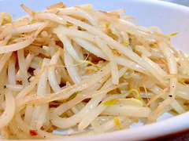

```python
img = PIL.Image.open(fn); img #viewing a sample image
```

```python
img.size
```

```
(240, 180)
```

```python
size_d = {k: PIL.Image.open(PATH + k).size for k in data.trn_ds.fnames}
```

```python
row_sz, col_sz = list(zip(*size_d.values()))
```

```python
row_sz = np.array(row_sz); col_sz = np.array(col_sz)
```

```python
row_sz[:5]
```

```
array([240, 240, 240, 240, 240])
```

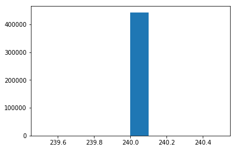

```python
plt.hist(row_sz);
#all images are 240 in height
```

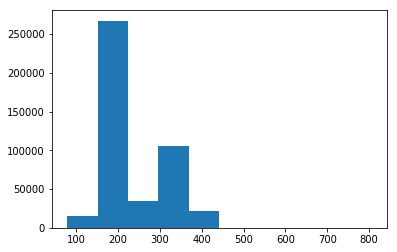

```python
plt.hist(col_sz);
```

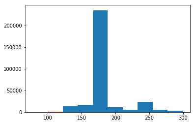

```python
plt.hist(col_sz[col_sz < 300])
#majority of images are 180 in width
```

```python
len(data.trn_ds), len(data.test_ds)  #training and test image count
```

```
(443724, 118863)
```

```python
len(data.classes), data.classes[:5]
```

```
(43, ['0', '1', '10', '11', '12'])
```

## Initial model

```python
def get_data(sz, bs): # sz: image size, bs: batch size
    tfms = tfms_from_model(arch, sz, aug_tfms=transforms_side_on, max_zoom=1.1)
    data = ImageClassifierData.from_csv(PATH, 'train', f'{PATH}train.csv', test_name='test',
                                       val_idxs=val_idxs, tfms=tfms, bs=bs)
    return data if sz > 300 else data.resize(340, 'tmp') # Reading the jpgs and resizing is slow for big images, so resizing them all to 340 first saves time
```

### Precompute

```python
data = get_data(sz, bs)
```

```python
learn = ConvLearner.pretrained(arch, data, precompute=True)
```

```python
learn.fit(1e-2, 5)
```

```
epoch      trn_loss   val_loss   accuracy
    0      2.08702    2.006719   0.442113
    1      2.05139    1.967818   0.454643
    2      2.062985   1.950188   0.45842
    3      2.006915   1.937726   0.460331
    4      1.967624   1.926281   0.463567
```

```
[array([1.92628]), 0.46356744235413305]
```

```python
learn.save('osho_1_0.4635')
```

## Choosing a learning rate

The *learning rate* determines how quickly or how slowly you want to update the *weights* (or *parameters*). Learning rate is one of the most difficult parameters to set, because it significantly affects model performance.

The method `learn.lr_find()` helps you find an optimal learning rate. It uses the technique developed in the 2015 paper [Cyclical Learning Rates for Training Neural Networks](http://arxiv.org/abs/1506.01186), where we simply keep increasing the learning rate from a very small value, until the loss stops decreasing. We can plot the learning rate across batches to see what this looks like.

We first create a new learner, since we want to know how to set the learning rate for a new (untrained) model.

```python
learn = ConvLearner.pretrained(arch, data, precompute=True)
```

```python
lrf=learn.lr_find()
```

Our learn object contains an attribute sched that contains our learning rate scheduler, and has some convenient plotting functionality including this one:

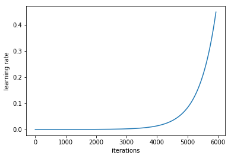

```python
learn.sched.plot_lr()
```

Note that in the previous plot *iteration* is one iteration (or *minibatch*) of SGD. In one epoch there are (num_train_samples/batch_size) iterations of SGD.

We can see the plot of loss versus learning rate to see where our loss stops decreasing:

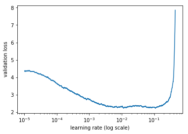

```python
learn.sched.plot()
```

### Augment

```python
from sklearn import metrics
```

```python
data = get_data(sz, 128)
```

```python
learn = ConvLearner.pretrained(arch, data, precompute=True, ps=0.5)
```

```python
learn.fit(1e-2, 2)
```

[output not shown]

```
[array([0.31262]), 0.9119373855058928]
```

```python
learn.precompute = False
```

```python
learn.fit(1e-2, 5, cycle_len=1)
```

[output not shown]

```
[array([0.25087]), 0.918786694858872]
```

```python
learn.save('224_pre')
```

```python
learn.load('224_pre')
```

## Increase size

```python
# Starting training on small images for a few epochs, then switching to bigger images, and continuing training is an amazingly effective way to avoid overfitting.

# http://forums.fast.ai/t/planet-classification-challenge/7824/96
# set_data doesn’t change the model at all. It just gives it new data to train with.
learn.set_data(get_data(299, bs))
learn.freeze()
```

```python
learn.summary()
```

[output not shown]

[output cut: 1441 more lines]

[output not shown]

```python
learn.fit(1e-2, 3, cycle_len=1)
```

[output not shown]

```
[array([0.23499]), 0.9192759310662629]
```

Validation loss is much lower than training loss. This is a sign of underfitting. Cycle_len=1 may be too short. Let's set cycle_mult=2 to find better parameter.

```python
# When you are under fitting, it means cycle_len=1 is too short (learning rate is getting reset before it had the chance to zoom in properly).
learn.fit(1e-2, 3, cycle_len=1, cycle_mult=2) # 1+2+4 = 7 epochs
```

[output not shown]

```
[array([0.22728]), 0.9261252481176895]
```

Training loss and validation loss are getting closer and smaller. We are on right track.

```python
log_preds, y = learn.TTA() # (5, 2044, 120), (2044,)
probs = np.mean(np.exp(log_preds),0)
accuracy_np(probs, y), metrics.log_loss(y, probs)
```

[output not shown]

```python
len(data.val_ds.y), data.val_ds.y[:5]
```

[output not shown]

```python
learn.save('299_pre')
```

```python
learn.load('299_pre')
```

```python
learn.fit(1e-2, 1, cycle_len=2) # 1+1 = 2 epochs
```

[output not shown]

```
[array([0.22462]), 0.9266144826337549]
```

```python
learn.save('299_pre')
```

```python
log_preds, y = learn.TTA()
probs = np.mean(np.exp(log_preds),0)
accuracy_np(probs, y), metrics.log_loss(y, probs)
```

[output not shown]

This dataset is so similar to ImageNet dataset. Training convolution layers doesn't help much. We are not going to unfreeze.

## Create submission

https://youtu.be/9C06ZPF8Uuc?t=1905

```python
data.classes
```

[output not shown]

[output cut: 65 more lines]

[output not shown]

```python
data.test_ds.fnames
```

[output not shown]

[output cut: 946 more lines]

[output not shown]

```python
log_preds, y = learn.TTA(is_test=True) # use test dataset rather than validation dataset
probs = np.mean(np.exp(log_preds),0)
#accuracy_np(probs, y), metrcs.log_loss(y, probs) # This does not make sense since test dataset has no labels
```

```python
probs.shape # (n_images, n_classes)
```

[output not shown]

```python
df = pd.DataFrame(probs)
df.columns = data.classes
```

```python
df.insert(0, 'id', [o[5:-4] for o in data.test_ds.fnames])
```

```python
df.head()
```

[output not shown]

```python
SUBM = f'{PATH}/subm/'
os.makedirs(SUBM, exist_ok=True)
df.to_csv(f'{SUBM}subm.gz', compression='gzip', index=False)
```

```python
FileLink(f'{SUBM}subm.gz')
```

## Individual prediction

```python
fn = data.val_ds.fnames[0]
fn
```

[output not shown]

[figure not shown]

```python
Image.open(PATH + fn).resize((150, 150))
```

```python
# Method 1.
trn_tfms, val_tfms = tfms_from_model(arch, sz)
ds = FilesIndexArrayDataset([fn], np.array([0]), val_tfms, PATH)
dl = DataLoader(ds)
preds = learn.predict_dl(dl)
np.argmax(preds)
```

```
19
```

```python
learn.data.classes[np.argmax(preds)]
```

[output not shown]

```python
# Method 2.
trn_tfms, val_tfms = tfms_from_model(arch, sz)
im = val_tfms(open_image(PATH + fn)) # open_image() returns numpy.ndarray
preds = learn.predict_array(im[None])
np.argmax(preds)
```

```
19
```